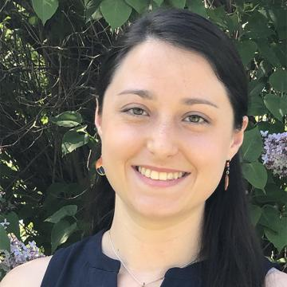

**Jaleigh Q. Pier**

Cornell University, Ithaca, NY 14850

jqp3@cornell.edu

### Education

- Cornell University, PhD anticipated 2025
- University of Connecticut, MS Ecology and Evolutionary Biology 2018
- St. Lawrence University, BS Geology, Biology 2016

### Profesional Experience

- **Intern Supervisor:** Training and supervising two undergraduate students in the labs at the Paleontological Research Institution in Ithaca, NY on a project looking at bioerosion traces in oyster shells to see if they correlate with changes in salinity. (January 2021-April 2021)

### Leadership Involvememt

- **IDEEAS Conflict Resolution Action Team:** A subset of IDEEAS members with the goal of providing a training or workshop on conflict resolution skills for the department to help foster conversations and have productive meetings to create deliverables/policy change for the department. (Fall 2021-Present)

### Science Oytreach Mentoring

- **Museum Exhibit:** The design and co-creation of graphics and video for a temporary exhibit, Conservation Paleobiology: Behind the scenes research at PRI, for Museum of the Earth, Ithaca NY. The exhibit highlights the Historical Oyster Body Size Project and is being used to conduct survey research. (Sept 2020-Present)

### Publications

- **Pier, J.Q.**, Brisson, S.K., Beard, J.A., Hren, M.T., and Bush, A.M. (2021). Accelerated mass extinction in an isolated biota during Late Devonian climate changes. Scientific Reports: 11, 24366. 10.1038/s41598-021-03510-6.